# Discretization

Erin Bennett

11/8/2018

# Binning vs Analytic Distribution for Priors

## Sorites priors

Prior distributions on prices are well-fit by a log-normal distribution. The concrete premise is “An X that costs $$x$ is expensive.” For this premise, we infer a price $x$ and a threshod $\theta$. The inductive premise is “An X that costs $$\varepsilon$ less than an expensive X is expensive.” For this premise, I think we basically end up inferring a price $x$ for the first object, then seeing how likey we’d be to infer a price $x-\varepsilon$ if we were told “expensive” vs. if we were told nothing. Then we sort of marginalize over that inferred price $x$. Something like:

$S2_I = \int_x L1(x | u)S2_C(u|x-\varepsilon)dx$

And I don’t know if there’s one $\theta$ inferred jointly here or if it’s separately marginalized over for the $L1$ and the $S2$. But either way, conceptually, all we really care about are three variables:

- $x$ := the price of the first X
- $x' = x-\varepsilon$ := the price of the second X
- $\theta$ := the threshold

We know the relationship between $x$ and $x'$ and we can assume they share the same underlying distribution of prics. We don’t know the relationship between the two prices and $\theta$, but $\theta$ is distributed uniformly over some range.

If we infer everything jointly, we’ll need a joint distribution that accounts for all the relationships between the variables. If we infer the prices separately, we could marginalize the joint distribution over all three variables to get a joint distribution of just two of them. That is, we could marginalize over $x'$ to get a joint distribution of $x$ and $\theta$ and use that distribution for the concrete premise, and we could marginalize over $x$ to get a joint distribution of $x'$ and $\theta$, using that distribution for the inductive premise.

So we can discretize the joint distribution over $x$, $x'$, and $\theta$ in such a way that we account for all possible relationships between variables.

Let’s assume prices for X fall in a standard lognormal distribution:

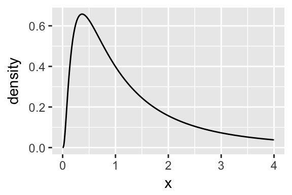

$P((a,b]) =\int_{x=a}^b P(x) dx$

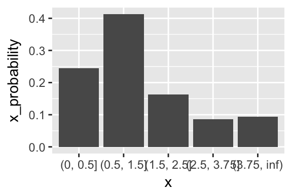

If $x$ and $\theta$ appear in different regions, we just take the product of the probabilities of the values falling in those regions.

$$P(x \in (a,b] \mbox{ AND } \theta \in (a', b']) =
\left(\Phi(\ln(b)) - \Phi(\ln(a)) \right)
\left(\frac{b'-a'}{\theta_{\max} - \theta_{\min}}\right)$$

But if they appear in the same region, we need the probability of falling in those regions AND the relationship. Let $t = \ln(x)$. Let $B = \min(\theta_{\max}, b)$. If $x \leq \theta$,

$$\begin{aligned}
P(x,\theta \in (a,b] \mbox{ AND } x < \theta)
=& \int_{\ln(a)}^{\ln(B)} \phi_{\mu,\sigma}(t)
\int_{e^t}^{B} \frac{1}{Z_\theta} d\theta dt \\
=& \frac{B}{Z_\theta} \int_{\ln(a)}^{\ln(B)} \phi_{\mu,\sigma}(t)dt -
\frac{1}{Z_\theta} \int_{\ln(a)}^{\ln(B)} e^t \phi_{\mu,\sigma}(t)dt \\
=& \frac{B}{Z_\theta}\left[\Phi_{\mu, \sigma}(t)\right]_{\ln(a)}^{\ln(B)} -
\frac{1}{Z_\theta} e^{\frac{1}{2}\sigma^2 + \mu}
\left[\Phi_{(\sigma^2+\mu), \sigma}(t)\right]_{\ln(a)}^{\ln(B)} \\
\end{aligned}$$

If $\theta<x$ and $b \leq \theta_{\max}$,

$$\begin{aligned}
P(x,\theta \in (a,b] \mbox{ AND } \theta < x)
=& \int_{\ln(a)}^{\ln(b)} \phi_{\mu,\sigma}(t)
\int_a^{e^t} \frac{1}{Z_\theta} d\theta dt \\
=& \frac{1}{Z_\theta} \int_{\ln(a)}^{\ln(b)} e^t \phi_{\mu,\sigma}(t)dt -
\frac{a}{Z_\theta} \int_{\ln(a)}^{\ln(b)} \phi_{\mu,\sigma}(t)dt \\
=& \frac{1}{Z_\theta}e^{\frac{1}{2}\sigma^2 + \mu}\left[\Phi_{(\sigma^2+\mu), \sigma}(t)\right]_{\ln(a)}^{\ln(b)} - \frac{a}{Z_\theta}\left[\Phi_{\mu, \sigma}(t)\right]_{\ln(a)}^{\ln(b)}
\end{aligned}$$

Or, if $\theta<x$ and $\theta_{\max} < b$,

$$\begin{aligned}
P(x,\theta \in (a,b] \mbox{ AND } \theta < x)
=& \int_{\ln(a)}^{\ln(\theta_{\max})} \phi_{\mu,\sigma}(t)
\int_a^{e^t} \frac{1}{Z_\theta} d\theta dt +
\int_{\ln(\theta_{\max})}^{\ln(b)} \phi_{\mu,\sigma}(t)
\int_{a}^{\theta_{\max}} \frac{1}{Z_\theta} d\theta dt \\
=& \frac{1}{Z_\theta}e^{\frac{1}{2}\sigma^2 + \mu}
\left[\Phi_{(\sigma^2+\mu), \sigma}(t)\right]_{\ln(a)}^{\ln(b)} -
\frac{a}{Z_\theta}
\left[\Phi_{\mu, \sigma}(t)\right]_{\ln(a)}^{\ln(b)} +
\frac{\theta_{\max} - a}{Z_\theta}
\left[\Phi_{\mu, \sigma}(t)\right]_{\ln(\theta_{\max})}^{\ln(b)}
\end{aligned}$$

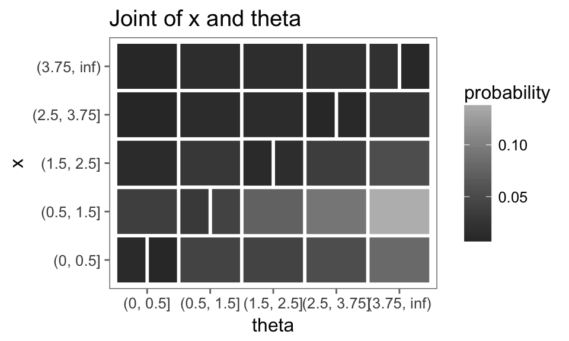

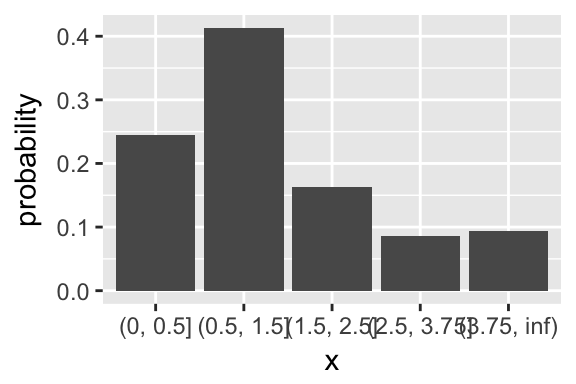

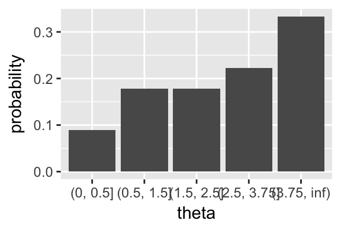

helpful links from MH: * https://github.com/mhtess/generic-interpretation/blob/master/models/node_modules/utils/utils.wppl * https://github.com/mhtess/generic-interpretation/blob/master/models/node_modules/utils/utils.js